# 01 - Custom ggplot2 themes

### **A basic scatter plot**

In this exercise, you will create a very basic scatter plot with `ggplot2`. This is mostly a repetition of stuff you’ve learnt in the prerequisites for this course, so it should be easy for you.

**Instructions**

- Filter the data for the year 2006. Save this filtered data set in a new variable called `plot_data` .
- Use `plot_data` to create a scatter plot with `working_hours` on the x-axis and `hourly_compensation` on the y-axis.

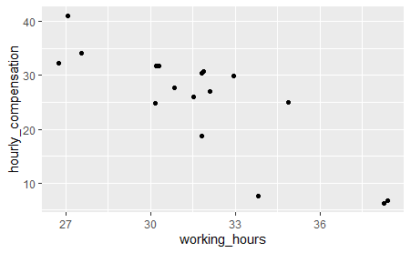

```r
# Filter for 2006
plot_data <- ilo_data %>%
  filter(year == 2006)

# Create the scatter plot
ggplot(plot_data) +
  geom_point(aes(x = working_hours, y = hourly_compensation))
```

### **Add labels to the plot**

As mentioned in the video, you’re going to enhance the plot from the previous exercise by adding a title, a subtitle, and a caption to the plot as well as giving the axes meaningful names. You’re going to use the `labs()` function to do this – try using `?labs` in the console to see the available options.

**Instructions**

- Use the `labs()` function to annotate your plot.
- Specify the correct arguments in the `labs` function call.
  - Use `?labs` to fire up the help function and see what arguments the `labs()` call takes.
  - While it should be clear to what arguments most of the annotations should go, `"The more people work, the less compensation they seem to receive"` should be the title of the plot.

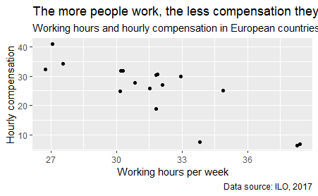

```r
# Create the plot
ggplot(plot_data) +
  geom_point(aes(x = working_hours, y = hourly_compensation)) +
  # Add labels
  labs(
    x = "Working hours per week",
    y = "Hourly compensation",
    title = "The more people work, the less compensation they seem to receive",
    subtitle = "Working hours and hourly compensation in European countries, 2006",
    caption = "Data source: ILO, 2017"
  )
```

## **Custom ggplot2 themes**

**1. Custom ggplot2 themes**

In the last set of exercises you created a very effective visualization that shows the relationship between two variables - the scatter plot. Now, let’s make it more special. And this is where custom ggplot2 themes come in handy.

**2. The advantages of a custom look**

**3. The `theme()` function**

The theme function is added to the plot object like geometries or other functions like labs. Within the theme function, you can alter components or elements of a theme, for instance all text elements, like in this example. In order to do that, you need to provide the appropriate argument with a function call from the element function family. In this case, element_text. Within this function call, you can specify a wide range of arguments that steer the look of this element. Here, we used the family and color argument to change all text elements in the plot to a gray serif font. Here, this affects the axes titles of the plot.

**4. Default ggplot2 themes**

ggplot2 also comes with a variety of default themes that you can just apply to your plot. They’ll change a lot of components at the same time. In the classic theme for example, grid lines are removed and the axes are more pronounced, just to name a few.

**5. Chaining `theme()` calls**

Another cool thing about themes is that they can be combined and chained together. For instance, we could apply the classic theme, but then overwrite some of its components. Here, we just added another theme call to overwrite the style of the text elements in the plot.

**6. Theme configuration options**

Custom themes allow you to change the style of basically all elements of your plot. You can get an overview of all configuration options by calling the documentation of the theme function. Theme options are very fine-grained, as this excerpt from the documentation shows. For instance, you can change the appearance of only the x-axis, while leaving the y-axis as it is. The documentation also shows which function from the element function family to use for each configuration option.

**7. The `element_*` function family**

**8. Let’s try out themes!**

Time to put this into practice. Let’s try out some themes.

### **Apply a default theme**

As you’ve learnt in the videos, `ggplot2` comes with a set of predefined themes. Try out some of them!

**Instructions**

1. Assign your plot object into a variable called `ilo_plot` so you can save some typing later on.
2. Try out the minimal theme on `ilo_plot`.
3. Try out another theme on `ilo_plot`.

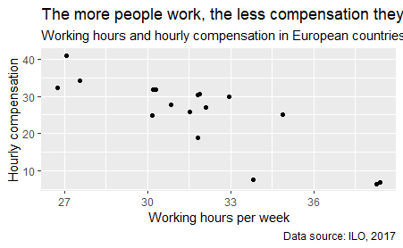

```r
# Save your current plot into a variable: ilo_plot
ilo_plot <- ggplot(plot_data) +
  geom_point(aes(x = working_hours, y = hourly_compensation)) +
  labs(
    x = "Working hours per week",
    y = "Hourly compensation",
    title = "The more people work, the less compensation they seem to receive",
    subtitle = "Working hours and hourly compensation in European countries, 2006",
    caption = "Data source: ILO, 2017"
  )

# View it
ilo_plot
```

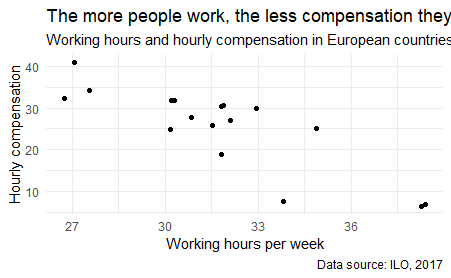

```r
# Add a minimal theme
ilo_plot +
  theme_minimal()
```

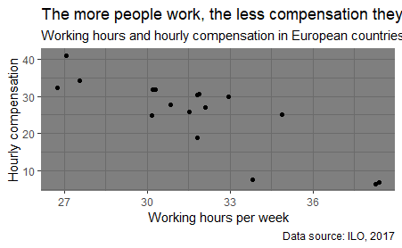

```r
# Add a different theme
ilo_plot +
  theme_dark()
```

### **Change the appearance of titles**

Besides applying defined `theme` presets, you can tweak your plot even more by altering different style attributes of it. Hint: You can reuse and overwrite the `ilo_plot` variable generated in the previous exercise – the current plot is already shown in the window on the right.

**Instructions**

- Using a custom `theme()` function call and `element_text()`:
  - Change the font `family` of the text to `"Bookman"`.
  - Additionally, change the `color` of the **title** and **caption** to `"gray25"` and `"gray30"`, respectively.
  - Make the **subtitle** a little bigger by increasing the `size` to 12.

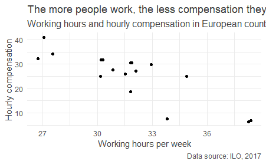

```r
ilo_plot <- ilo_plot +
  theme_minimal() +
  # Customize the "minimal" theme with another custom "theme" call
  theme(
    text = element_text(family = "Bookman"),
    title = element_text(color = "gray25"),
    plot.caption = element_text(color = "gray30"),
    plot.subtitle = element_text(size = 12)
  )

# Render the plot object
ilo_plot
```

### **Alter background color and add margins**

Further customize the look of your plot with more arguments to the `theme` function call. You can continue working on your `ilo_plot` object created in the last exercise.

**Instructions**

- Change the overall background color of your plot to `"gray95"`.
  - This time, another function than `element_text` is needed – one for rectangular plot elements. Rewatch the video to know which.
- Look up the **correct sequence** of margin specifications in the documentation by typing `?theme`.
- Using these specifications, add margins to the plot: 5mm top and bottom, 10mm to the left and the right.

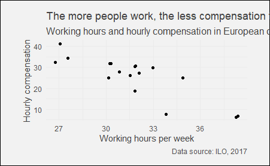

```r
ilo_plot +
  # "theme" calls can be stacked upon each other, so this is already the third call of "theme"
  theme(
    plot.background = element_rect(fill = "gray95"),
    plot.margin = unit(c(5, 10, 5, 10), units = "mm")
  )
```